# Problem Set 3

Omry Yoresh

2023-06-01

Load libraries:

```r
library(tidyverse)
library(magrittr)
library(tidymodels)
library(caret)
library(DALEX)
library(rpart)
library(rattle)
library(rpart.plot)
library(RColorBrewer)
library(ada)
library(doParallel)
library(pROC)
```

More setting:

```r
cl <- makePSOCKcluster(5)
registerDoParallel(cl)
```

Set path:

```r
PATH <- "/Users/omry/Documents/GitHub/Hebrew-University/Machine Learning (F23)"
setwd(PATH)
```

Setting the seed:

```r
set.seed(167)
```

### Preface

*Q.1*: Why we are not tuning parameters in OLS or Logistic Regression? How do we estimate these models?

*A.1*: In OLS and logistic regressions we minimize the square errors and maximize the likelihood function respectively. We do this in order to find the optimum of these two objectives. In economics, we have interest in certain coefficients and therefore we do not tune the variable, because we have a particular parametric model in mind, and often units help us with interpretability. Variables have their own meaning, and we can’t allow to throw out important variables if they are of importance to the structure of the estimation – prime example of a problem that might arise is omitted variable bias.

*Q.2*: Can we infer causality from interpretability?

*A.2*: No, but ‘interpretability’ is necessary in order to establish causality. We usually think of a story, a mechanism which is in play and after we make claims.

Loading the data:

```r
heart <- read_csv("data/ml4econ ex2 heart.csv") %>%
    as_tibble() %>%
  mutate(target = as.factor(target))

wine <- read_csv("data/ml4econ ex2 winequality_red.csv")
```

Splitting the data into 70% train and 30% test:

```r
wine_split <- wine %>%
  initial_split(prop=7/10)

wine_train <- training(wine_split)
wine_test  <- testing(wine_split)

heart_split <- heart %>%
  initial_split(prop=7/10)

heart_train <- training(heart_split)
heart_test  <- testing(heart_split)
```

### Models

**Trees:**

*Q.3*: Why simple trees are considered as path dependent? Why simple trees suffer from over-fitting?

*A.3*: Trees are considered path dependent because the “leafs” (the splits) occur within previous leafs and do not adjust previous decision (“greedy” algorithm). The reason that they suffer from over-fitting is because the choice of splits is based on minimizing the residual sum of square, which at the limits is extremely unique to the training data set.

```r
formula_part <- target ~ sex + cp + chol
formula_full <- target ~ .
```

```r
tree_fit <- rpart(
  formula_part,
  data = heart_train,
  method = "class"
)
```

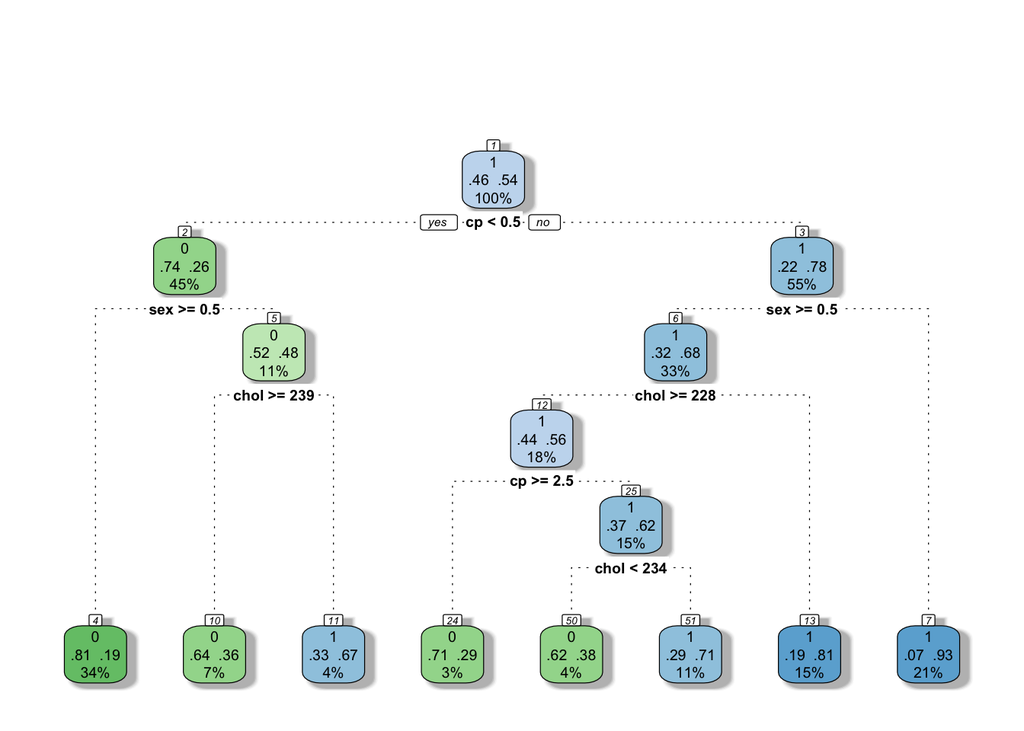

```r
fancyRpartPlot(tree_fit, caption = NULL)
```

```r
model1 <- rpart(
  formula_full,
  data = heart_train,
  method = "class",
  control = rpart.control(minsplit = 2, minbucket = 1)
)
model2 <- rpart(
  formula_full,
  data = heart_train,
  method = "class"
)
```

```r
printcp(model1) # this model uses 12 different variables
```

```
##
## Classification tree:
## rpart(formula = formula_full, data = heart_train, method = "class",
##     control = rpart.control(minsplit = 2, minbucket = 1))
##
## Variables actually used in tree construction:
##  [1] age      ca       chol     cp       exang    oldpeak  restecg  sex
##  [9] slope    thal     thalach  trestbps
##
## Root node error: 97/212 = 0.45755
##
## n= 212
##
##         CP nsplit rel error  xerror     xstd
## 1 0.474227      0   1.00000 1.00000 0.074782
## 2 0.072165      1   0.52577 0.62887 0.067954
## 3 0.051546      3   0.38144 0.55670 0.065401
## 4 0.020619      4   0.32990 0.56701 0.065795
## 5 0.010309     11   0.15464 0.54639 0.064998
## 6 0.010000     16   0.10309 0.62887 0.067954
```

```r
printcp(model2) # this model uses 8 different variables
```

```
##
## Classification tree:
## rpart(formula = formula_full, data = heart_train, method = "class")
##
## Variables actually used in tree construction:
## [1] age     ca      chol    cp      exang   oldpeak sex     thal
##
## Root node error: 97/212 = 0.45755
##
## n= 212
##
##         CP nsplit rel error  xerror     xstd
## 1 0.474227      0   1.00000 1.00000 0.074782
## 2 0.072165      1   0.52577 0.57732 0.066178
## 3 0.051546      3   0.38144 0.53608 0.064584
## 4 0.027491      4   0.32990 0.43299 0.059829
## 5 0.020619      7   0.24742 0.45361 0.060875
## 6 0.010000      8   0.22680 0.45361 0.060875
```

**Generating predictions based on both models:**

```r
pred_model1_train <- predict(model1, heart_train, type = "class")
pred_model2_train <- predict(model2, heart_train, type = "class")
pred_model1_test <- predict(model1, heart_test, type = "class")
pred_model2_test <- predict(model2, heart_test, type = "class")
```

**Generating corresponding confusion matrices and summarizing their accuracy**

```r
train_confmat1 <- bind_cols(heart_train$target, pred_model1_train) %>%
  conf_mat(...1, ...2)

train_confmat1 %>%
  summary() %>%
  filter(.metric %in% c("accuracy", "sens", "spec")) %>%
  mutate("1-.estimate" = 1 - .estimate)
```

```
## # A tibble: 3 × 4
##   .metric  .estimator .estimate `1-.estimate`
##   <chr>    <chr>          <dbl>         <dbl>
## 1 accuracy binary         0.953        0.0472
## 2 sens     binary         0.918        0.0825
## 3 spec     binary         0.983        0.0174
```

```r
train_confmat2 <- bind_cols(heart_train$target, pred_model2_train) %>%
  conf_mat(...1, ...2)

train_confmat2 %>%
  summary() %>%
  filter(.metric %in% c("accuracy", "sens", "spec")) %>%
  mutate("1-.estimate" = 1 - .estimate)
```

```
## # A tibble: 3 × 4
##   .metric  .estimator .estimate `1-.estimate`
##   <chr>    <chr>          <dbl>         <dbl>
## 1 accuracy binary         0.896        0.104
## 2 sens     binary         0.876        0.124
## 3 spec     binary         0.913        0.0870
```

```r
test_confmat1 <- bind_cols(heart_test$target, pred_model1_test) %>%
  conf_mat(...1, ...2)

test_confmat1 %>%
  summary() %>%
  filter(.metric %in% c("accuracy", "sens", "spec")) %>%
  mutate("1-.estimate" = 1 - .estimate)
```

```
## # A tibble: 3 × 4
##   .metric  .estimator .estimate `1-.estimate`
##   <chr>    <chr>          <dbl>         <dbl>
## 1 accuracy binary         0.824         0.176
## 2 sens     binary         0.878         0.122
## 3 spec     binary         0.78          0.22
```

```r
test_confmat2 <- bind_cols(heart_test$target, pred_model2_test) %>%
  conf_mat(...1, ...2)

test_confmat2 %>%
  summary() %>%
  filter(.metric %in% c("accuracy", "sens", "spec")) %>%
  mutate("1-.estimate" = 1 - .estimate)
```

```
## # A tibble: 3 × 4
##   .metric  .estimator .estimate `1-.estimate`
##   <chr>    <chr>          <dbl>         <dbl>
## 1 accuracy binary         0.802        0.198
## 2 sens     binary         0.902        0.0976
## 3 spec     binary         0.72         0.28
```

**Pruning the tree and limiting it’s complexity:**

```r
model1_prune <- prune(model1, cp = 0.03)
model2_prune <- prune(model2, cp = 0.03)
```

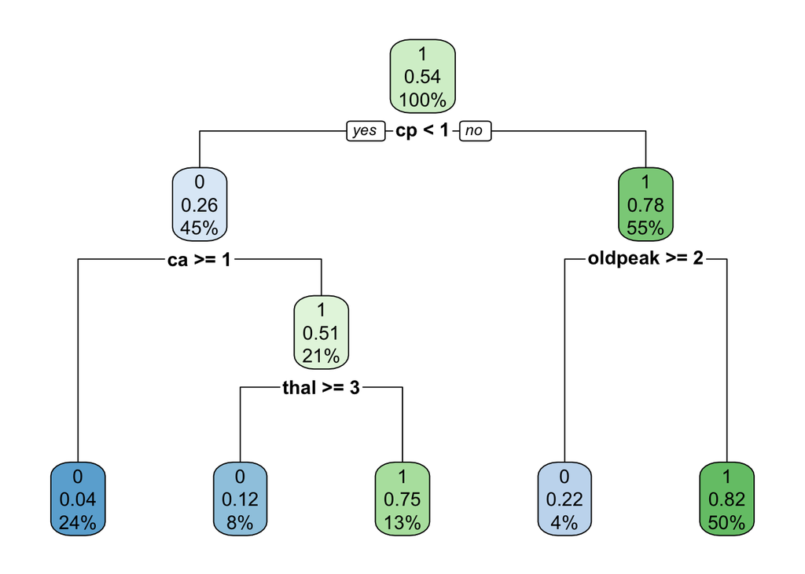

```r
rpart.plot(model1_prune)
rpart.plot(model2_prune)
```

```r
# Model predictions in train and test sets
pred_prune_train <- predict(model1_prune, heart_train, type = "class")
pred_prune_test <- predict(model1_prune, heart_test, type = "class")
```

```r
train_confmat_prune <- bind_cols(heart_train$target, pred_prune_train) %>%
  conf_mat(...1, ...2)

train_confmat_prune %>%
  summary() %>%
  filter(.metric %in% c("accuracy", "sens", "spec")) %>%
  mutate("1-.estimate" = 1 - .estimate)
```

```
## # A tibble: 3 × 4
##   .metric  .estimator .estimate `1-.estimate`
##   <chr>    <chr>          <dbl>         <dbl>
## 1 accuracy binary         0.849        0.151
## 2 sens     binary         0.732        0.268
## 3 spec     binary         0.948        0.0522
```

```r
test_confmat_prune <- bind_cols(heart_test$target, pred_prune_test) %>%
  conf_mat(...1, ...2)

test_confmat_prune %>%
  summary() %>%
  filter(.metric %in% c("accuracy", "sens", "spec")) %>%
  mutate("1-.estimate" = 1 - .estimate)
```

```
## # A tibble: 3 × 4
##   .metric  .estimator .estimate `1-.estimate`
##   <chr>    <chr>          <dbl>         <dbl>
## 1 accuracy binary         0.813         0.187
## 2 sens     binary         0.829         0.171
## 3 spec     binary         0.8           0.2
```

We see that the accuracy is closer between the training and test data-set, suggesting less over-fitting.

### K-Nearest Neighbors (KNN)

**Cross-Validation:**

```r
fitControl <- trainControl(
  method = "repeatedcv",
  number = 5, #5-fold repeated cv
  repeats = 3
)
```

**Fitting a model:**

```r
KNN <- train(
  formula_full,
  data = heart_train,
  method = "knn",
  trControl = fitControl
)

bagging <- train(
  formula_full,
  data = heart_train,
  method = "ada",
  trControl = fitControl
)

boosting <- train(
  formula_full,
  data = heart_train,
  method = "gbm",
  trControl = fitControl
)

random_forest <- train(
  formula_full,
  data = heart_train,
  method = "rf",
  trControl = fitControl
)
```

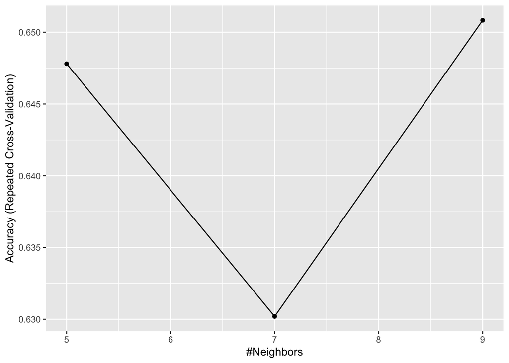

```r
ggplot(KNN)
```

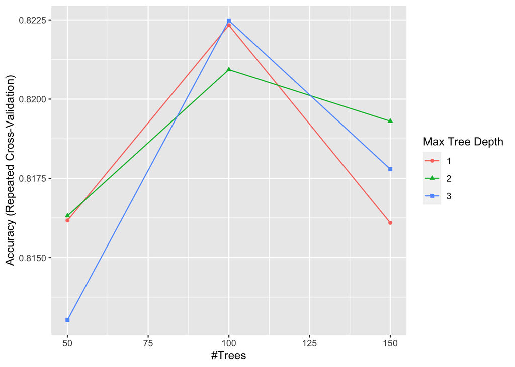

```r
ggplot(bagging)
```

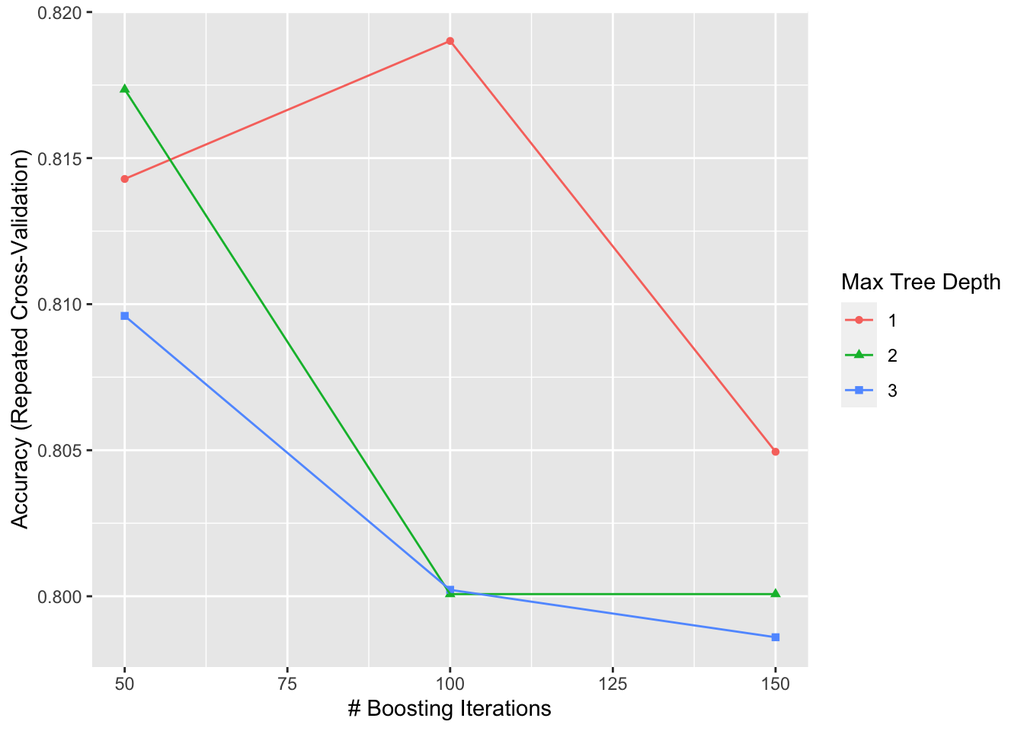

```r
ggplot(boosting)
```

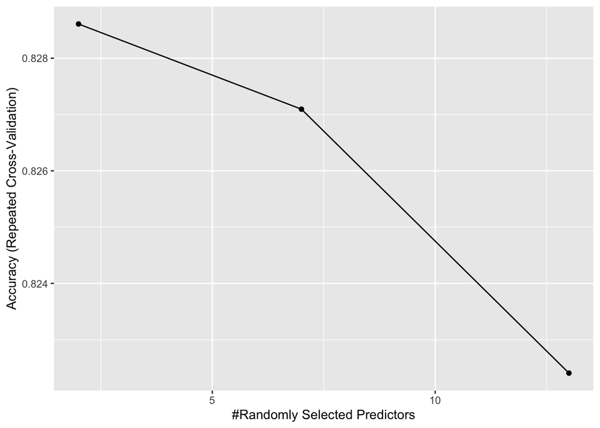

```r
ggplot(random_forest)
```

**User-Defined Grid:**

```r
boosting_grid <- expand.grid(
  interaction.depth = c(1,5,9),
  n.trees = (1:30)*50,
  shrinkage = 0.1,
  n.minobsinnode = 20
)
```

```r
new_boosting <- train(
  formula_full,
  data = heart_train,
  method = "gbm",
  trControl = fitControl,
  tuneGrid = boosting_grid
)
```

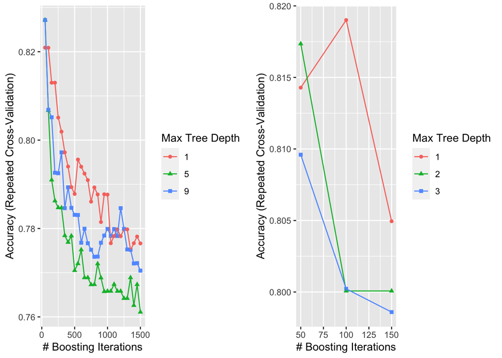

```r
gridExtra::grid.arrange(ggplot(new_boosting),ggplot(boosting), ncol = 2)
```

### Interpretability

**Explain objects:**

```r
KNN_explainer <- explain(
  KNN,
  label = "knn",
  x = heart_train %>% select(-target),
  y = as.numeric(as.character(heart_train$target))
)
```

```
## Preparation of a new explainer is initiated
##   -> model label       :  knn
##   -> data              :  212  rows  14  cols  extracted from the model
##   -> target variable   :  212  values
##   -> predict function  :  yhat.train  will be used (  default  )
##   -> predicted values  :  No value for predict function target column. (  default  )
##   -> model_info        :  package caret , ver. 6.0.94 , task classification (  default  )
##   -> predicted values  :  numerical, min =  0 , mean =  0.5569849 , max =  1
##   -> residual function :  difference between y and yhat (  default  )
##   -> residuals         :  numerical, min =  -0.8888889 , mean =  -0.01453211 , max =  0.7777778
##   A new explainer has been created!
```

```r
bagging_explainer <- explain(
  bagging,
  label = "ada",
  x = heart_train %>% select(-target),
  y = as.numeric(as.character(heart_train$target))
)
```

```
## Preparation of a new explainer is initiated
##   -> model label       :  ada
##   -> data              :  212  rows  14  cols  extracted from the model
##   -> target variable   :  212  values
##   -> predict function  :  yhat.train  will be used (  default  )
##   -> predicted values  :  No value for predict function target column. (  default  )
##   -> model_info        :  package caret , ver. 6.0.94 , task classification (  default  )
##   -> predicted values  :  numerical, min =  0.00137036 , mean =  0.5529512 , max =  0.9978347
##   -> residual function :  difference between y and yhat (  default  )
##   -> residuals         :  numerical, min =  -0.8852072 , mean =  -0.01049836 , max =  0.7126504
##   A new explainer has been created!
```

```r
boosting_explainer <- explain(
  new_boosting,
  label = "gbm",
  x = heart_train %>% select(-target),
  y = as.numeric(as.character(heart_train$target))
)
```

```
## Preparation of a new explainer is initiated
##   -> model label       :  gbm
##   -> data              :  212  rows  14  cols  extracted from the model
##   -> target variable   :  212  values
##   -> predict function  :  yhat.train  will be used (  default  )
##   -> predicted values  :  No value for predict function target column. (  default  )
##   -> model_info        :  package caret , ver. 6.0.94 , task classification (  default  )
##   -> predicted values  :  numerical, min =  0.01297308 , mean =  0.5440208 , max =  0.9899315
##   -> residual function :  difference between y and yhat (  default  )
##   -> residuals         :  numerical, min =  -0.8630197 , mean =  -0.001567921 , max =  0.7705201
##   A new explainer has been created!
```

```r
random_forest_explainer <- explain(
  random_forest,
  label = "rf",
  x = heart_train %>% select(-target),
  y = as.numeric(as.character(heart_train$target))
)
```

```
## Preparation of a new explainer is initiated
##   -> model label       :  rf
##   -> data              :  212  rows  14  cols  extracted from the model
##   -> target variable   :  212  values
##   -> predict function  :  yhat.train  will be used (  default  )
##   -> predicted values  :  No value for predict function target column. (  default  )
##   -> model_info        :  package caret , ver. 6.0.94 , task classification (  default  )
##   -> predicted values  :  numerical, min =  0 , mean =  0.5504717 , max =  1
##   -> residual function :  difference between y and yhat (  default  )
##   -> residuals         :  numerical, min =  -0.532 , mean =  -0.008018868 , max =  0.36
##   A new explainer has been created!
```

**Model Performance:**

```r
KNN_mp <- model_performance(KNN_explainer)
bagging_mp <- model_performance(bagging_explainer)
boosting_mp <- model_performance(boosting_explainer)
random_forest_mp <- model_performance(random_forest_explainer)
```

```r
line <- plot(KNN_mp, bagging_mp, boosting_mp, random_forest_mp)
box <- plot(KNN_mp, bagging_mp, boosting_mp, random_forest_mp, geom = "boxplot")
```

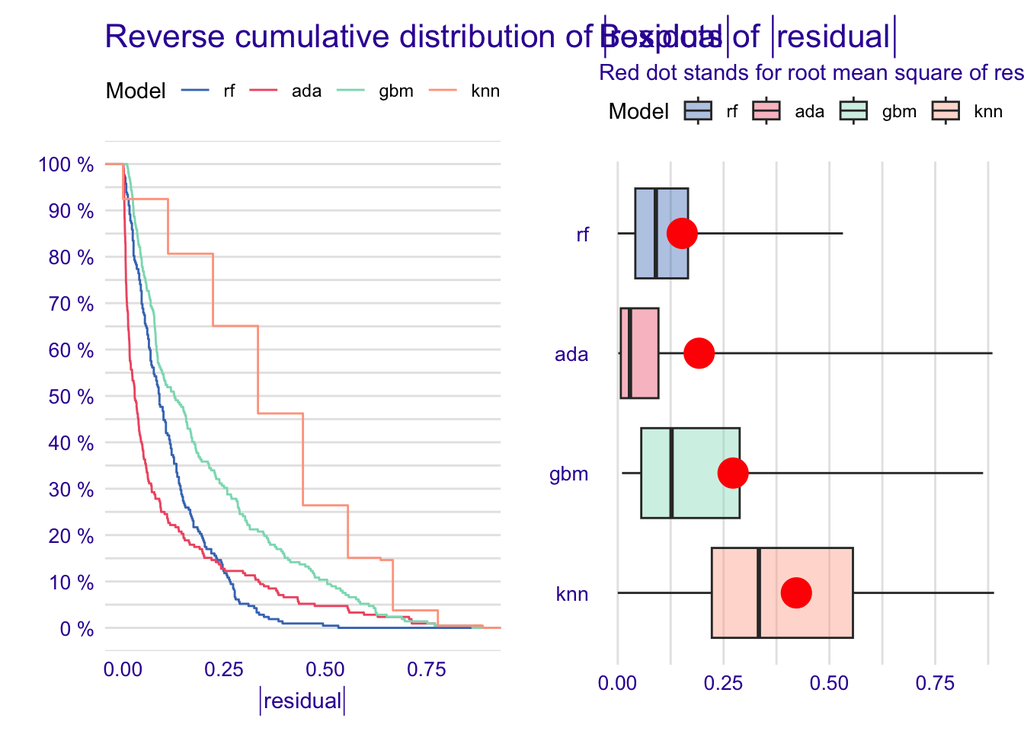

```r
gridExtra::grid.arrange(line, box, ncol = 2)
```

The left graph shows the cumulative distribution of the residuals It describes the percent of the predictions that are above a each level from the actual value. The right graph describes the same data in a boxplot format.

**Variable Importance:**

```r
KNN_vip <- variable_importance(KNN_explainer)
bagging_vip <- variable_importance(bagging_explainer)
boosting_vip <- variable_importance(boosting_explainer)
random_forest_vip <- variable_importance(random_forest_explainer)
```

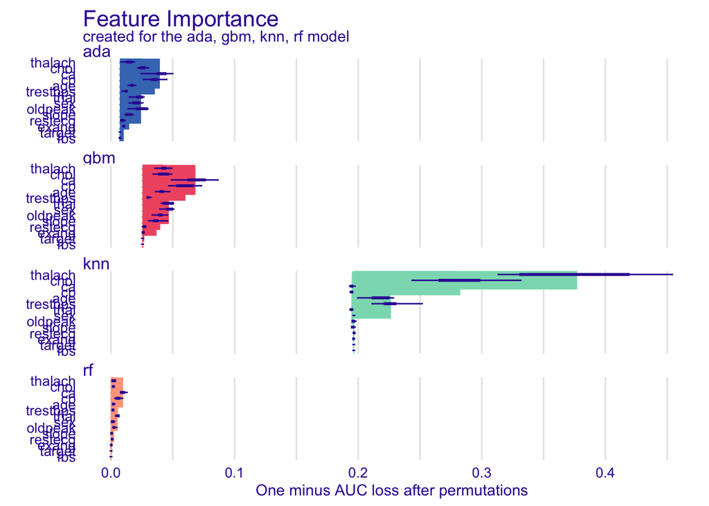

```r
plot(KNN_vip, bagging_vip, boosting_vip, random_forest_vip)
```

The biggest bars corresponds with the most important variables, in terms of the models’ ability to predict.

**Partial Dependence:**

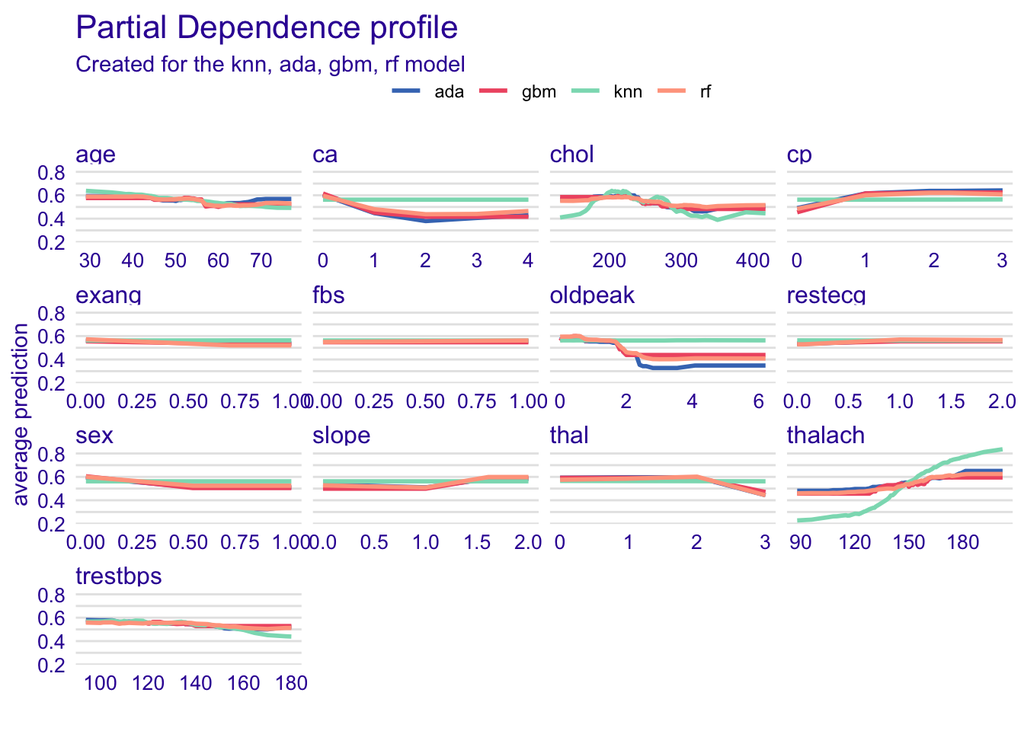

```r
KNN_ve <- model_profile(KNN_explainer)
bagging_ve <- model_profile(bagging_explainer)
boosting_ve <- model_profile(boosting_explainer)
random_forest_ve <- model_profile(random_forest_explainer)

plot(KNN_ve, bagging_ve, boosting_ve, random_forest_ve)
```

**Breakdown:**

```r
heart_row <- heart_train[1,]
KNN_breakdown <- predict_parts_break_down(KNN_explainer, new_observation = heart_row)
bagging_breakdown <- predict_parts_break_down(bagging_explainer, new_observation = heart_row)
boosting_breakdown <- predict_parts_break_down(boosting_explainer, new_observation = heart_row)
random_forest_breakdown <- predict_parts_break_down(random_forest_explainer, new_observation = heart_row)
```

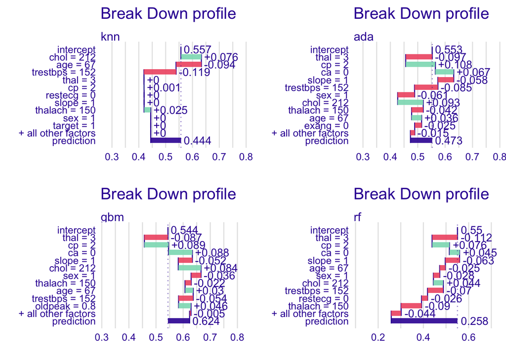

```r
gridExtra::grid.arrange(
  plot(KNN_breakdown),
  plot(bagging_breakdown),
  plot(boosting_breakdown),
  plot(random_forest_breakdown),
  ncol = 2
)
```

**Predict:**

```r
KNN_pred <- predict(KNN, newdata = heart_test)
bagging_pred <- predict(bagging, newdata = heart_test)
boosting_pred <- predict(boosting, newdata = heart_test)
random_forest_pred <- predict(random_forest, newdata = heart_test)
```

**ROC:**

```r
KNN_roc <- bind_cols(fct_rev(heart_test$target), as.numeric(KNN_pred)) %>%
  roc_curve(...1, ...2) %>%
  mutate(model = "knn")

bagging_roc <- bind_cols(fct_rev(heart_test$target), as.numeric(bagging_pred)) %>%
  roc_curve(...1, ...2) %>%
  mutate(model = "ada")

boosting_roc <- bind_cols(fct_rev(heart_test$target), as.numeric(boosting_pred)) %>%
  roc_curve(...1, ...2) %>%
  mutate(model = "gbm")

random_forest_roc <- bind_cols(fct_rev(heart_test$target), as.numeric(random_forest_pred)) %>%
  roc_curve(...1, ...2) %>%
  mutate(model = "rf")
```

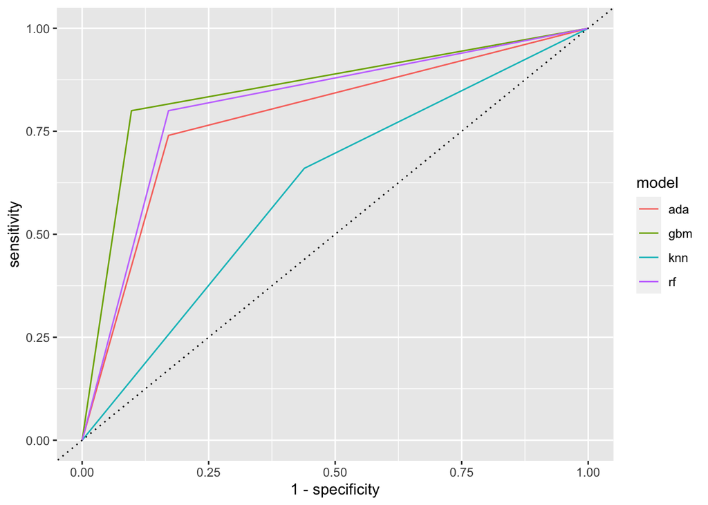

```r
rbind(KNN_roc, bagging_roc, boosting_roc, random_forest_roc) %>%
  ggplot(aes(x = 1 - specificity, y = sensitivity, color = model)) +
  geom_path() +
  geom_abline(lty = 3)
```

```r
bind_cols(fct_rev(heart_test$target), as.numeric(boosting_pred)) %>%
  roc_auc(...1, ...2)
```

```
## # A tibble: 1 × 3
##   .metric .estimator .estimate
##   <chr>   <chr>          <dbl>
## 1 roc_auc binary         0.851
```

The area under the curve for the boosting model is 0.85.